# Adding annotations to scRNAseq analyses

```r
library(Seurat)
library(dplyr)
```

```r
library(ggplot2)
library(pheatmap)
library(EnhancedVolcano)
```

Load in files

```r
name = "LDAVMO2_Trial"
dir = "~/Desktop/Sequencing/LD_AVM02"
genefilename = "Macrophage_only_all_markers.csv"
peaksfilename = "MergedpeaksPBSAnnotated_v2.csv"
specfilename = "barreslab_rnaseq.csv" #courtesy of https://brainrnaseq.org
velocityfilename = "spliced_unspliced_ratio.csv"
velocitygenefile = "splicegenes.csv"
cellphonedbfile = "significant_means.csv"
impclusters = c(3,4,5,8)
alpha = 1e-25
foldchange = 1.15
```

```r
de = read.csv(file.path(dir,"Spreadsheets",genefilename),stringsAsFactors = F)
#genes = read.csv("https://github.com/lcdorman/scrnaseq/blob/master/allmarkers_vargenesMG_0501.csv",stringsAsFactors = F)
peaks = read.csv(file.path(dir,"Spreadsheets",peaksfilename),stringsAsFactors = F)
#peaks = read.csv("https://github.com/lcdorman/scrnaseq/blob/master/MergedpeaksPBSAnnotated_v2.csv",stringsAsFactors = F)
barres = read.csv(file.path(dir,"Spreadsheets",specfilename),stringsAsFactors = F)
#barres = read.csv("https://github.com/lcdorman/scrnaseq/blob/master/barreslab_rnaseq.csv",stringsAsFactors = F)

ratio = read.csv(file.path(dir,"Spreadsheets",velocityfilename),header = F)
#ratio = read.csv("https://github.com/lcdorman/scrnaseq/blob/master/spliced_unspliced_ratio.csv",stringsAsFactors = F,header = F)

velocitygenes = read.csv(file.path(dir,"Spreadsheets",velocitygenefile),stringsAsFactors = F)
#velocitygenes = read.csv("https://github.com/lcdorman/scrnaseq/blob/master/splicegenes.csv",stringsAsFactors = F)

cellphonedb = read.csv(file.path(dir,"Spreadsheets",cellphonedbfile),stringsAsFactors = F)
#cellphonedb = read.csv("https://github.com/lcdorman/scrnaseq/blob/master/significant_means.csv",stringsAsFactors = F)
```

Determine “cells of interest” for calculating cell type specificity in barres dataset. only change “coi”

```r
colnames(barres)
```

```
## [1] "Gene.symbol"                    "Description"
## [3] "Astrocytes"                     "Neuron"
## [5] "Oligodendrocyte.Precursor.Cell" "Newly.Formed.Oligodendrocyte"
## [7] "Myelinating.Oligodendrocytes"   "Microglia"
## [9] "Endothelial.Cells"
```

```r
coi = 8
other = c(3:(coi-1),(coi+1):9)
```

Load file with differentially expressed genes

```r
#remove excess columns
genes = de[,3:ncol(de)]
head(genes)
```

|  | avg_logFC | pct.1 | pct.2 | p_val_adj | cluster | gene |
| --- | --- | --- | --- | --- | --- | --- |
| 1 | 2.112061 | 0.999 | 0.343 | 0 | 1 | Hist1h1b |
| 2 | 2.060259 | 0.999 | 0.377 | 0 | 1 | Hist1h2ap |
| 3 | 1.961455 | 0.999 | 0.270 | 0 | 1 | Hist1h2ae |
| 4 | 1.857180 | 1.000 | 0.372 | 0 | 1 | Top2a |
| 5 | 1.848683 | 1.000 | 0.411 | 0 | 1 | Mki67 |
| 6 | 1.504864 | 1.000 | 0.791 | 0 | 1 | Hist1h1e |

```r
#remove genes that don't pass a threshold for p-value and log fold change
alpha = 1e-25
lfoldchange = 0.2

genes = genes[genes$p_val_adj<alpha,]
genes = genes[genes$avg_logFC > lfoldchange | genes$avg_logFC < -lfoldchange,]
```

Load file with atac-seq peaks and edit to merge each gene into one line

```r
head(peaks)
```

|  | PeakID..cmd.annotatePeaks.pl.MergedpeaksPBS.txt.mm10. | Chr | Start | End | Strand | Peak.Score | Focus.Ratio.Region.Size | Annotation | Detailed.Annotation | Distance.to.TSS | Nearest.PromoterID | Entrez.ID | Nearest.Unigene | Nearest.Refseq | Nearest.Ensembl | Gene.Name | Gene.Alias | Gene.Description | Gene.Type |
| --- | --- | --- | --- | --- | --- | --- | --- | --- | --- | --- | --- | --- | --- | --- | --- | --- | --- | --- | --- |
| 1 | Merged-chr7-45589315-4 | chr7 | 45589241 | 45589396 | + | 69.3500 | Sample5peaks.txt\|Sample6peaks.txt\|Sample7peaks.txt\|Sample8peaks.txt | exon (NM_009737, exon 11 of 11) | exon (NM_009737, exon 11 of 11) | -14142 | NR_038165 | 71661 | Mm.439894 | NR_038165 | ENSMUSG00000109644 | 0610005C13Rik | AI182092 | RIKEN cDNA 0610005C13 gene | ncRNA |
| 2 | Merged-chr11-51688720-4 | chr11 | 51688638 | 51688793 | + | 70.1250 | Sample5peaks.txt\|Sample6peaks.txt\|Sample7peaks.txt\|Sample8peaks.txt | promoter-TSS (NM_025319) | promoter-TSS (NM_025319) | -81 | NM_025319 | 66050 | Mm.35693 | NM_025319 | ENSMUSG00000007777 | 0610009B22Rik | - | RIKEN cDNA 0610009B22 gene | protein-coding |
| 3 | Merged-chr11-51693711-1 | chr11 | 51693651 | 51693771 | + | 6.8600 | Sample7peaks.txt | 3' UTR (NM_175255, exon 23 of 23) | 3' UTR (NM_175255, exon 23 of 23) | -5077 | NM_025319 | 66050 | Mm.35693 | NM_025319 | ENSMUSG00000007777 | 0610009B22Rik | - | RIKEN cDNA 0610009B22 gene | protein-coding |
| 4 | Merged-chr11-51681689-4 | chr11 | 51681549 | 51681810 | + | 6.7825 | Sample5peaks.txt\|Sample6peaks.txt\|Sample7peaks.txt\|Sample8peaks.txt | Intergenic | Intergenic | 6955 | NM_025319 | 66050 | Mm.35693 | NM_025319 | ENSMUSG00000007777 | 0610009B22Rik | - | RIKEN cDNA 0610009B22 gene | protein-coding |
| 5 | Merged-chr11-120350302-4 | chr11 | 120350201 | 120350408 | + | 22.2250 | Sample5peaks.txt\|Sample6peaks.txt\|Sample7peaks.txt\|Sample8peaks.txt | intron (NR_038126, intron 1 of 1) | CpG | 1626 | NR_038126 | 66838 | Mm.375010 | NR_038126 | ENSMUSG00000043644 | 0610009L18Rik | - | RIKEN cDNA 0610009L18 gene | ncRNA |
| 6 | Merged-chr11-120353760-4 | chr11 | 120353612 | 120353903 | + | 19.0000 | Sample5peaks.txt\|Sample6peaks.txt\|Sample7peaks.txt\|Sample8peaks.txt | Intergenic | Intergenic | 5079 | NR_038126 | 66838 | Mm.375010 | NR_038126 | ENSMUSG00000043644 | 0610009L18Rik | - | RIKEN cDNA 0610009L18 gene | ncRNA |

```r
peaks = peaks[,c("Peak.Score","Focus.Ratio.Region.Size","Detailed.Annotation","Gene.Name")]
head(peaks)
```

|  | Peak.Score | Focus.Ratio.Region.Size | Detailed.Annotation | Gene.Name |
| --- | --- | --- | --- | --- |
| 1 | 69.3500 | Sample5peaks.txt\|Sample6peaks.txt\|Sample7peaks.txt\|Sample8peaks.txt | exon (NM_009737, exon 11 of 11) | 0610005C13Rik |
| 2 | 70.1250 | Sample5peaks.txt\|Sample6peaks.txt\|Sample7peaks.txt\|Sample8peaks.txt | promoter-TSS (NM_025319) | 0610009B22Rik |
| 3 | 6.8600 | Sample7peaks.txt | 3' UTR (NM_175255, exon 23 of 23) | 0610009B22Rik |
| 4 | 6.7825 | Sample5peaks.txt\|Sample6peaks.txt\|Sample7peaks.txt\|Sample8peaks.txt | Intergenic | 0610009B22Rik |
| 5 | 22.2250 | Sample5peaks.txt\|Sample6peaks.txt\|Sample7peaks.txt\|Sample8peaks.txt | CpG | 0610009L18Rik |
| 6 | 19.0000 | Sample5peaks.txt\|Sample6peaks.txt\|Sample7peaks.txt\|Sample8peaks.txt | Intergenic | 0610009L18Rik |

Change “Detailed.Annotation” to specific meaningful values

```r
annotation = peaks$Detailed.Annotation
rpt = grep("repeat",annotation)
names(rpt) = rep("Repeat",length(rpt))

#pull out different kinds of annotations
prom = grep("promoter",annotation)
names(prom) = rep("Promoter",length(prom))

intergenic = grep("Intergenic",annotation)
names(intergenic) = rep("Intergenic",length(intergenic))

cpg = grep("CpG",annotation)
names(cpg) = rep("CpG",length(cpg))

utr3 = grep("3' UTR",annotation)
names(utr3) = rep("UTR3",length(utr3))

utr5 = grep("5' UTR",annotation)
names(utr5) = rep("UTR5",length(utr5))

exon = grep("exon",annotation)
names(exon) = rep("Exon",length(exon))
exon = exon[!exon %in% c(utr3,utr5)]

intron = grep("intron",annotation)
names(intron) = rep("Intron",length(intron))

tts = grep("TTS",annotation)
names(tts) = rep("TTS",length(tts))

annotationfull = c(rpt,exon,prom,intergenic,cpg,utr3,utr5,intron,tts)
annotationfull = annotationfull[order(annotationfull)]

annotation[annotationfull] = names(annotationfull)
```

Annotate peaks

```r
peaks$Detailed.Annotation = annotation

#Separate only the genes that are present in my file
allgenes = genes$gene
peaks = peaks[peaks$Gene.Name %in% allgenes,]

#Include only confident peaks (> 1 sample)
peaks = peaks[grep("\\|",peaks$Focus.Ratio.Region.Size),]
head(peaks)
```

|  | Peak.Score | Focus.Ratio.Region.Size | Detailed.Annotation | Gene.Name |
| --- | --- | --- | --- | --- |
| 11 | 22.500 | Sample5peaks.txt\|Sample6peaks.txt\|Sample7peaks.txt\|Sample8peaks.txt | Promoter | 0610012G03Rik |
| 222 | 44.150 | Sample5peaks.txt\|Sample6peaks.txt\|Sample7peaks.txt\|Sample8peaks.txt | Promoter | 1700003F12Rik |
| 476 | 46.525 | Sample5peaks.txt\|Sample6peaks.txt\|Sample7peaks.txt\|Sample8peaks.txt | Intergenic | 1700025G04Rik |
| 477 | 24.100 | Sample5peaks.txt\|Sample6peaks.txt\|Sample7peaks.txt\|Sample8peaks.txt | Promoter | 1700025G04Rik |
| 478 | 18.975 | Sample5peaks.txt\|Sample6peaks.txt\|Sample7peaks.txt\|Sample8peaks.txt | Intron | 1700025G04Rik |
| 479 | 13.225 | Sample5peaks.txt\|Sample6peaks.txt\|Sample7peaks.txt\|Sample8peaks.txt | Intron | 1700025G04Rik |

Select only the genes with promoter peaks (skip or change “Promoter” based on what you are interested in looking at)

```r
peaks = peaks[peaks$Detailed.Annotation == "Promoter",]
peaks = peaks[order(peaks$Peak.Score,decreasing = T),]
head(peaks)
```

|  | Peak.Score | Focus.Ratio.Region.Size | Detailed.Annotation | Gene.Name |
| --- | --- | --- | --- | --- |
| 57202 | 219.350 | Sample5peaks.txt\|Sample6peaks.txt\|Sample7peaks.txt\|Sample8peaks.txt | Promoter | Xpo1 |
| 25275 | 216.100 | Sample5peaks.txt\|Sample6peaks.txt\|Sample7peaks.txt\|Sample8peaks.txt | Promoter | Hjurp |
| 10921 | 204.450 | Sample5peaks.txt\|Sample6peaks.txt\|Sample7peaks.txt\|Sample8peaks.txt | Promoter | Cdca2 |
| 28465 | 199.375 | Sample5peaks.txt\|Sample6peaks.txt\|Sample7peaks.txt\|Sample8peaks.txt | Promoter | Klf6 |
| 25391 | 196.925 | Sample5peaks.txt\|Sample6peaks.txt\|Sample7peaks.txt\|Sample8peaks.txt | Promoter | Hmgb2 |
| 38899 | 185.925 | Sample5peaks.txt\|Sample6peaks.txt\|Sample7peaks.txt\|Sample8peaks.txt | Promoter | Pdia4 |

Merge every annotation for the same gene into one line.

```r
k = ncol(peaks)
for (i in 2:length(peaks$Gene.Name)){
  if (peaks$Gene.Name[(i-1)] == peaks$Gene.Name[i]){
    peaks[(i-(k/4)),(k+1):(k+4)] = peaks[i,1:4]
    k = k+4
  } else {k = 4}
}

peaks = peaks[!duplicated(peaks$Gene.Name),]
head(peaks)
```

|  | Peak.Score | Focus.Ratio.Region.Size | Detailed.Annotation | Gene.Name |
| --- | --- | --- | --- | --- |
| 57202 | 219.350 | Sample5peaks.txt\|Sample6peaks.txt\|Sample7peaks.txt\|Sample8peaks.txt | Promoter | Xpo1 |
| 25275 | 216.100 | Sample5peaks.txt\|Sample6peaks.txt\|Sample7peaks.txt\|Sample8peaks.txt | Promoter | Hjurp |
| 10921 | 204.450 | Sample5peaks.txt\|Sample6peaks.txt\|Sample7peaks.txt\|Sample8peaks.txt | Promoter | Cdca2 |
| 28465 | 199.375 | Sample5peaks.txt\|Sample6peaks.txt\|Sample7peaks.txt\|Sample8peaks.txt | Promoter | Klf6 |
| 25391 | 196.925 | Sample5peaks.txt\|Sample6peaks.txt\|Sample7peaks.txt\|Sample8peaks.txt | Promoter | Hmgb2 |
| 38899 | 185.925 | Sample5peaks.txt\|Sample6peaks.txt\|Sample7peaks.txt\|Sample8peaks.txt | Promoter | Pdia4 |

Select only the annotations for genes in your file, and save for future reference

```r
peaks = peaks[match(genes$gene,peaks$Gene.Name),]
atac =cbind(genes,peaks)
write.csv(atac,file = file.path(dir,"Spreadsheets",paste0(name,"atacseq_degenes_promoters.csv")))
```

Make a new spreadsheet with only the genes upregulated in a specific cluster

```r
clusters = levels(as.factor(genes$cluster))
for (cluster in clusters){
  genes_cluster = genes[genes$cluster == cluster,]
  peaks_cluster = peaks[peaks$Gene.Name %in% genes_cluster$gene,]
  dim(peaks_cluster)
  head(peaks_cluster)
  write.csv(peaks_cluster,file.path(dir,"Spreadsheets",paste0(name,"_Peaks_cluster",cluster,".csv")))
}
```

Calculate a cell type specificity rating for your cell type of interest (in this case, microglia)

This function will calculate a Cell Type specificity by dividing the fpkm for your cell type by the average fpkm for all other cell types.

```r
for (i in 1:nrow(barres)){
  row = barres[i,]
  mspec = as.numeric(row[coi])/mean(as.numeric(row[other]),na.rm = T)
  barres[i,10] = mspec
}
colnames(barres)[10] = "Specificity"
```

Add the barres annotation to the atac-seq gene datasheet

```r
barres = barres[match(atac$gene,barres$Gene.symbol),]
dim(atac)
```

```
## [1] 2675   10
```

```r
dim(barres)
```

```
## [1] 2675   10
```

```r
atac = cbind(barres,atac)
atac$Gene.symbol = atac$gene
head(atac)
```

|  | Gene.symbol | Description | Astrocytes | Neuron | Oligodendrocyte.Precursor.Cell | Newly.Formed.Oligodendrocyte | Myelinating.Oligodendrocytes | Microglia | Endothelial.Cells | Specificity | avg_logFC | pct.1 | pct.2 | p_val_adj | cluster | gene | Peak.Score | Focus.Ratio.Region.Size | Detailed.Annotation | Gene.Name |
| --- | --- | --- | --- | --- | --- | --- | --- | --- | --- | --- | --- | --- | --- | --- | --- | --- | --- | --- | --- | --- |
| 9485 | Hist1h1b | Histone cluster 1, H1b | 0.3 | 0.1 | 0.1 | 0.1 | 0.1 | 0.1 | 0.1 | 0.7500000 | 2.112061 | 0.999 | 0.343 | 0 | 1 | Hist1h1b | NA | NA | NA | NA |
| NA | Hist1h2ap | NA | NA | NA | NA | NA | NA | NA | NA | NA | 2.060259 | 0.999 | 0.377 | 0 | 1 | Hist1h2ap | NA | NA | NA | NA |
| 9494 | Hist1h2ae | Histone cluster 1, H2ae | 0.4 | 0.3 | 0.4 | 0.9 | 1.6 | 0.4 | 0.7 | 0.5581395 | 1.961455 | 0.999 | 0.270 | 0 | 1 | Hist1h2ae | 60.950 | Sample5peaks.txt\|Sample6peaks.txt\|Sample7peaks.txt\|Sample8peaks.txt | Promoter | Hist1h2ae |
| 20336 | Top2a | Topoisomerase (DNA) II alpha 170kDa | 7.7 | 0.8 | 11.1 | 0.9 | 0.1 | 0.9 | 6.9 | 0.1963636 | 1.857180 | 1.000 | 0.372 | 0 | 1 | Top2a | 66.425 | Sample5peaks.txt\|Sample6peaks.txt\|Sample7peaks.txt\|Sample8peaks.txt | Promoter | Top2a |
| 12443 | Mki67 | Antigen identified by monoclonal antibody Ki-67 | 4.6 | 0.8 | 4.8 | 0.3 | 0.1 | 0.3 | 2.3 | 0.1395349 | 1.848683 | 1.000 | 0.411 | 0 | 1 | Mki67 | 99.650 | Sample5peaks.txt\|Sample6peaks.txt\|Sample7peaks.txt\|Sample8peaks.txt | Promoter | Mki67 |
| 9488 | Hist1h1e | Histone cluster 1, H1e | 1.7 | 0.4 | 0.5 | 2.4 | 4.9 | 0.5 | 0.2 | 0.2970297 | 1.504864 | 1.000 | 0.791 | 0 | 1 | Hist1h1e | 43.550 | Sample5peaks.txt\|Sample6peaks.txt\|Sample7peaks.txt\|Sample8peaks.txt | Promoter | Hist1h1e |

Save the annotated file

```r
write.csv(atac,file = file.path(dir,"Spreadsheets",paste0(name,"_atacseqwithbarres_promoters_",colnames(barres)[coi],"_specificity.csv")))
```

Relationship between peak size and microglial specificity by cluster

```r
a = as.data.frame(cbind("Gene" = atac$Gene.symbol,"Cluster" = atac$cluster,"Specificity" = atac$Specificity,"Peak" = atac$Peak.Score,"avg_logfc" = atac$avg_logFC))

a$Peak = as.character(a$Peak)
a$Peak = as.numeric(a$Peak)

a$Specificity = as.character(a$Specificity)
a$Specificity = as.numeric(a$Specificity)

a$Cluster = as.character(a$Cluster)
head(a)
```

|  | Gene | Cluster | Specificity | Peak | avg_logfc |
| --- | --- | --- | --- | --- | --- |
| 1 | Hist1h1b | 1 | 0.7500000 | NA | 2.11206101595536 |
| 2 | Hist1h2ap | 1 | NA | NA | 2.0602589490311 |
| 3 | Hist1h2ae | 1 | 0.5581395 | 60.950 | 1.96145532345496 |
| 4 | Top2a | 1 | 0.1963636 | 66.425 | 1.85718009847278 |
| 5 | Mki67 | 1 | 0.1395349 | 99.650 | 1.84868275700493 |
| 6 | Hist1h1e | 1 | 0.2970297 | 43.550 | 1.50486429863683 |

adding in spliced:unspliced ratio calculated in scvelo (see scvelo_mgavm02 script for details)

```r
ratio = as.numeric(ratio[1,])
names(ratio) = velocitygenes$Name
```

add ratios to the spreadsheet a

```r
ratio = ratio[match(a$Gene,names(ratio))]
a$splicedratio = ratio
```

Peak chromatin score vs splicedratio

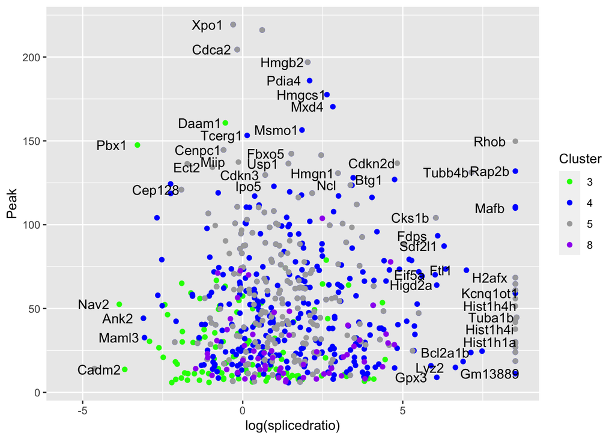

```r
ac = a[a$Cluster %in% impclusters,]
ac = ac[!is.na(ac$Peak),]
ac = ac[!is.na(ac$splicedratio),]
ac$splicedratio[ac$splicedratio == "Inf"] =5000

b <- ggplot(ac, aes(x = log(splicedratio), y = Peak))

c = b + geom_point(aes(color = Cluster)) +
  scale_color_manual(values = c('green','blue','darkgrey','purple')) + geom_text(
    data=ac %>% filter(log(splicedratio)>6 | log(splicedratio)<(-3) | Peak>120),
    aes(label=Gene),nudge_x = -0.8,check_overlap = T)
c
```

```r
setEPS()
postscript(file.path(dir,"Plots",paste0(name,"atacseqpeak_vs_splicedratio.eps")))
c
dev.off()
```

Peak chromatin score vs specificity

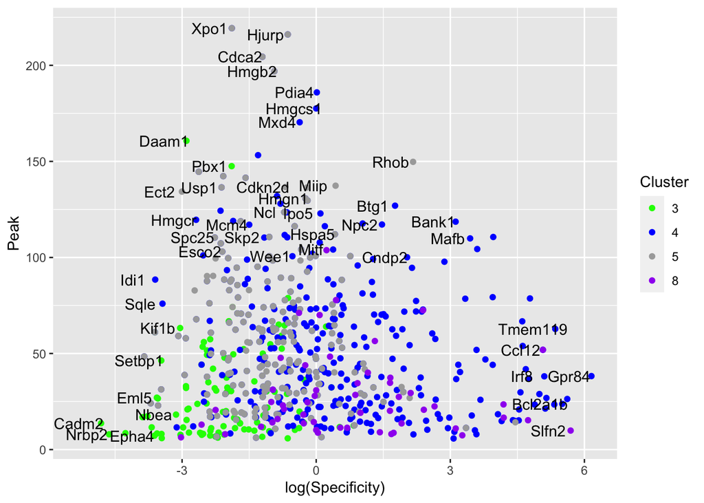

```r
b <- ggplot(ac, aes(y = Peak, x = log(Specificity)))

c = b + geom_point(aes(color = Cluster)) +
  scale_color_manual(values = c('green','blue','darkgrey','purple')) + geom_text(
    data=ac %>% filter(log(Specificity)>5 | log(Specificity)<(-3) | Peak>100),aes(label=Gene),nudge_x = -0.5,check_overlap = T)
print(c)
```

```r
setEPS()
postscript(file.path(dir,"Plots",paste0(name,colnames(barres)[coi],"specificity_peak.eps")))
c
dev.off()
```

Specificity vs spliced:unspliced ratio

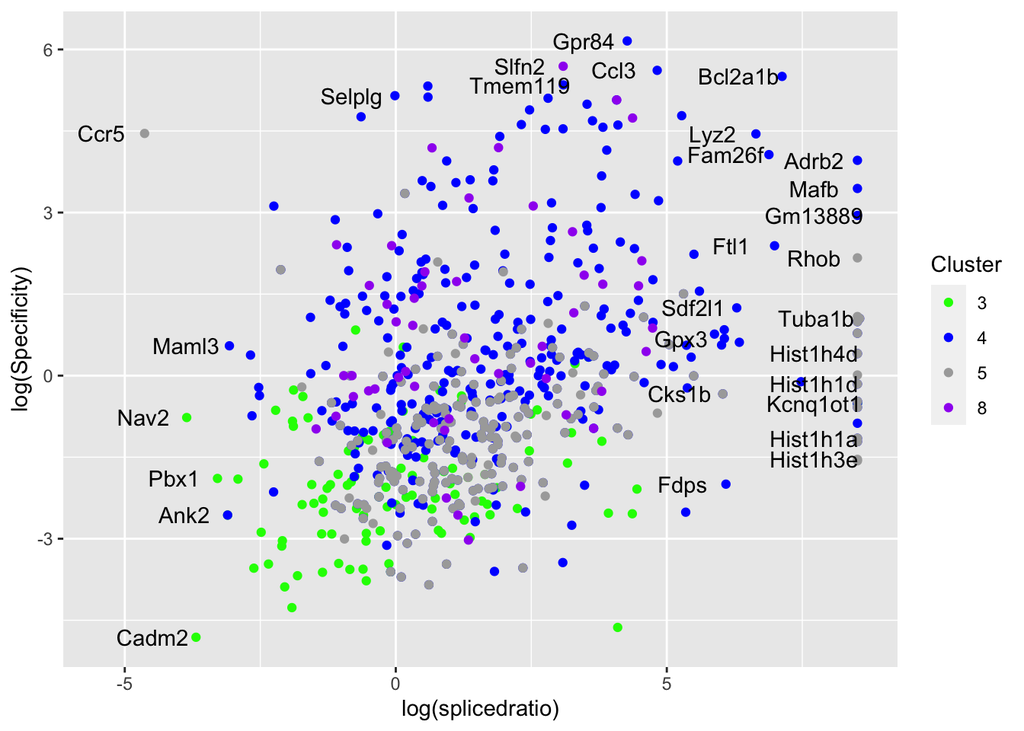

```r
b <- ggplot(ac, aes(x = log(splicedratio), y = log(Specificity)))
c = b + geom_point(aes(color = Cluster)) +
  scale_color_manual(values = c('green','blue','darkgrey','purple')) + geom_text(
    data=ac %>% filter(log(splicedratio)>6 | log(splicedratio)<(-3) | log(Specificity)>5),
    aes(label=Gene),nudge_x = -0.8,check_overlap = T)
print(c)
```

```r
setEPS()
postscript(file.path(dir,"Plots",paste0(name,colnames(barres)[coi],"specificity_splicedratio.eps")))
c
dev.off()
```

Volcano Plot:

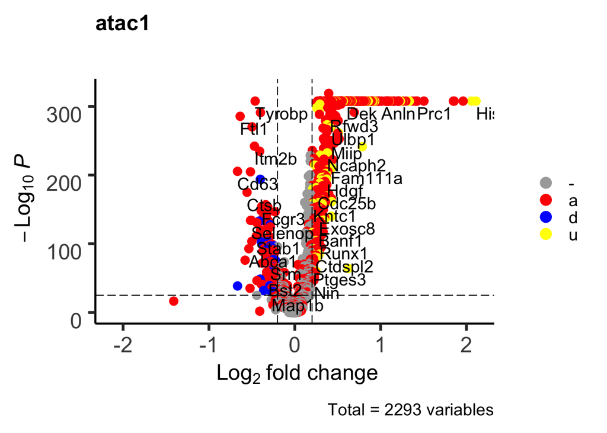

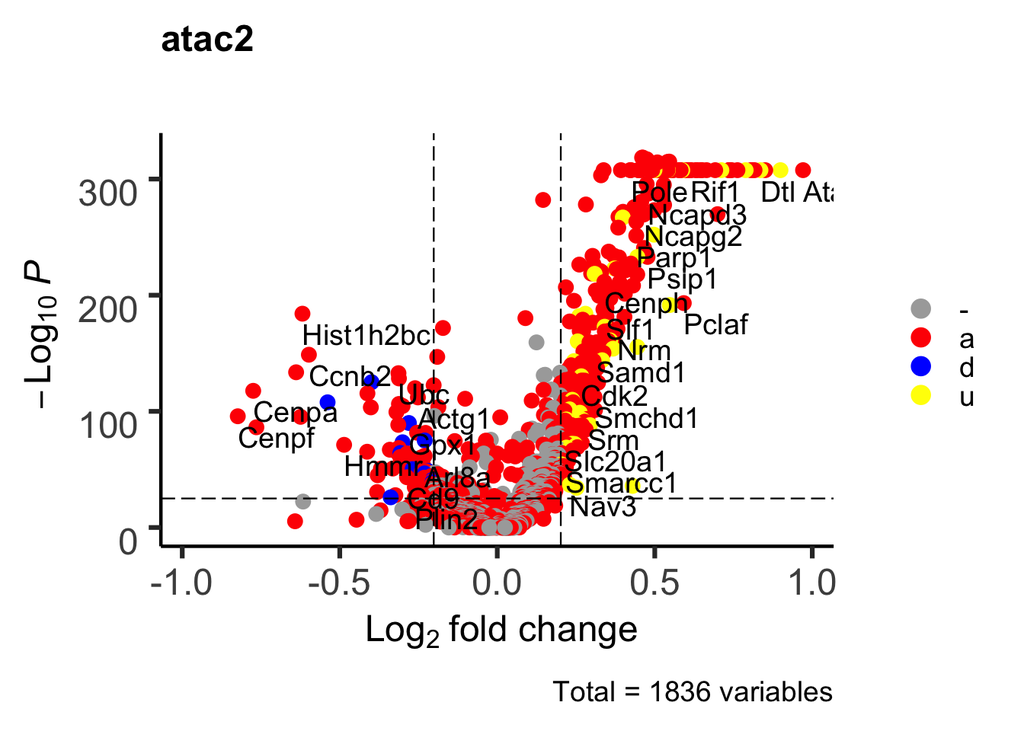

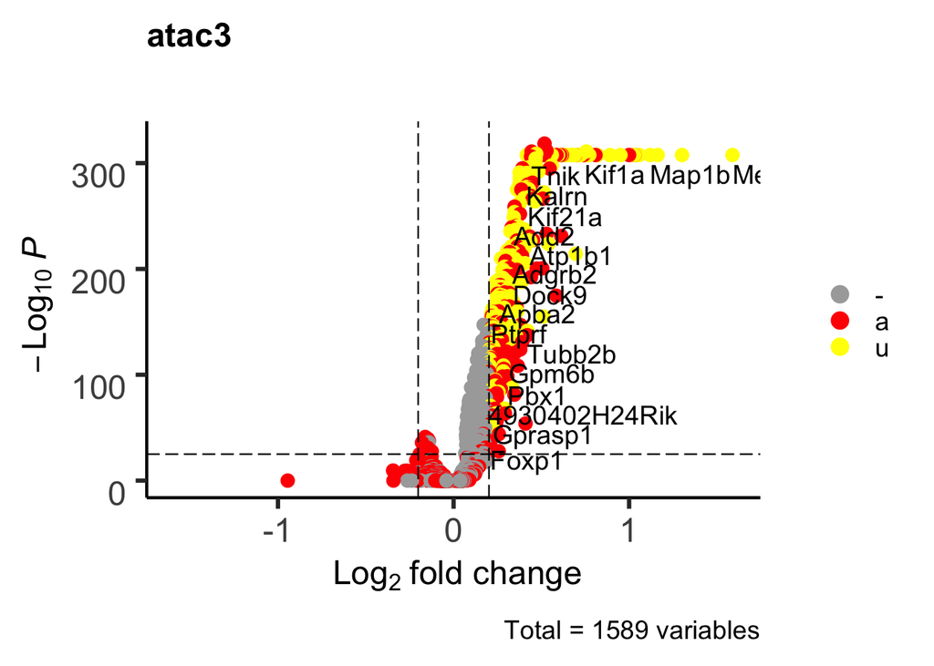

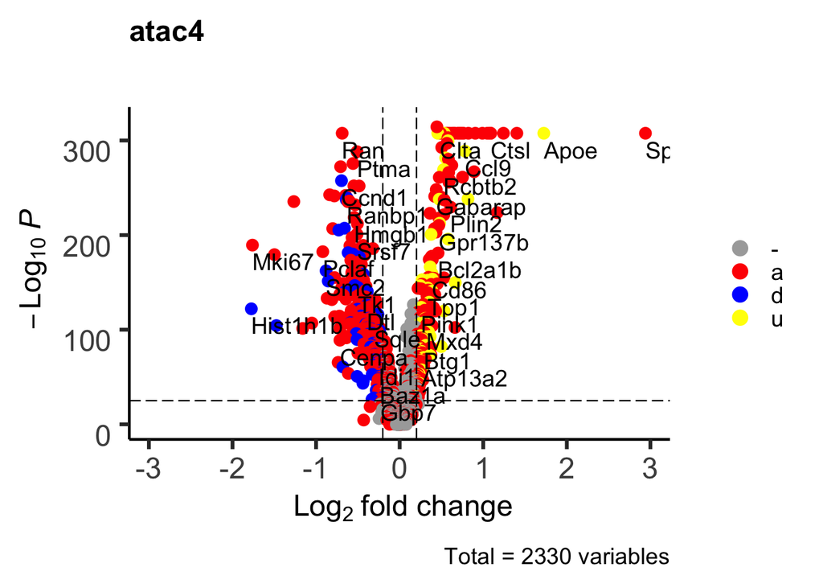

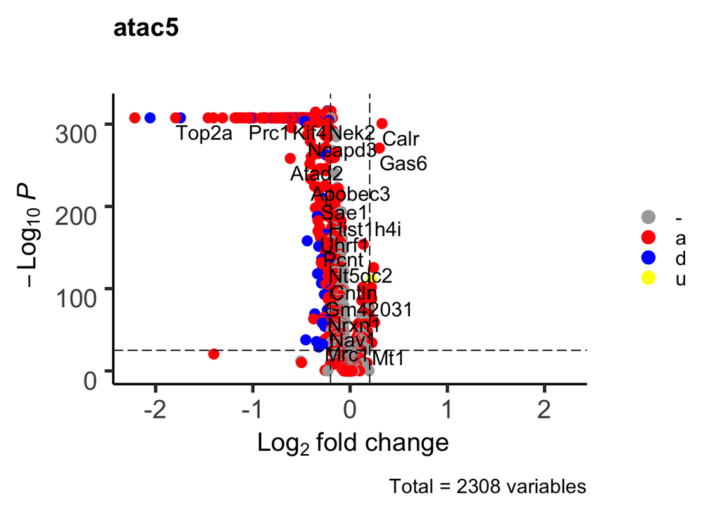

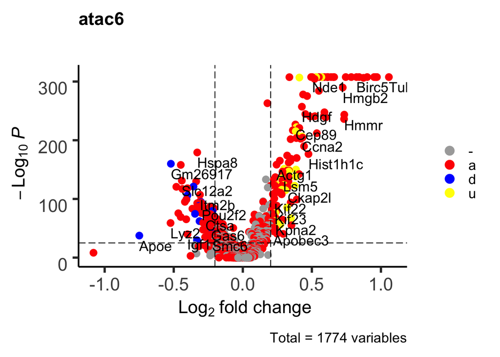

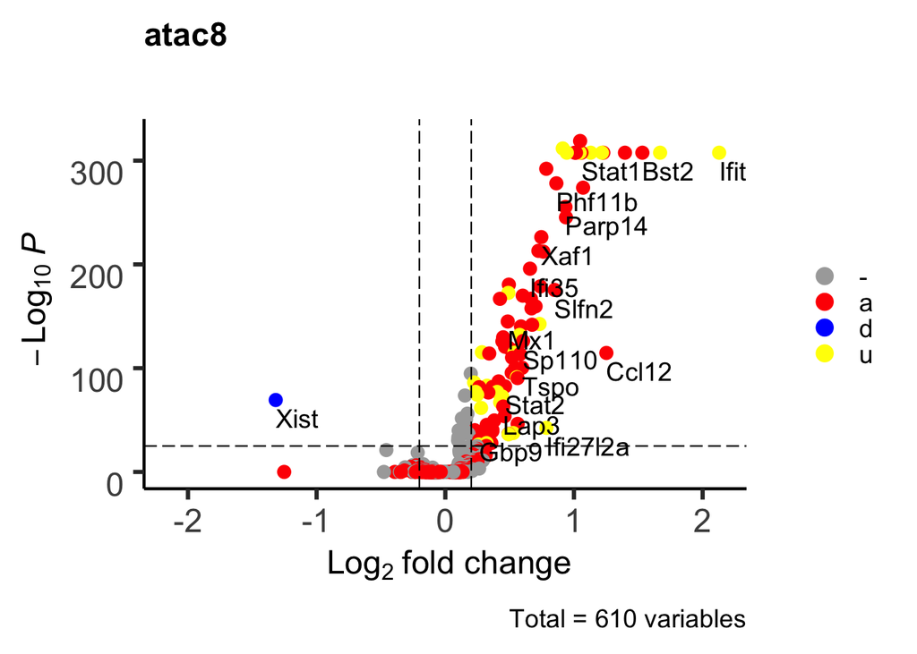

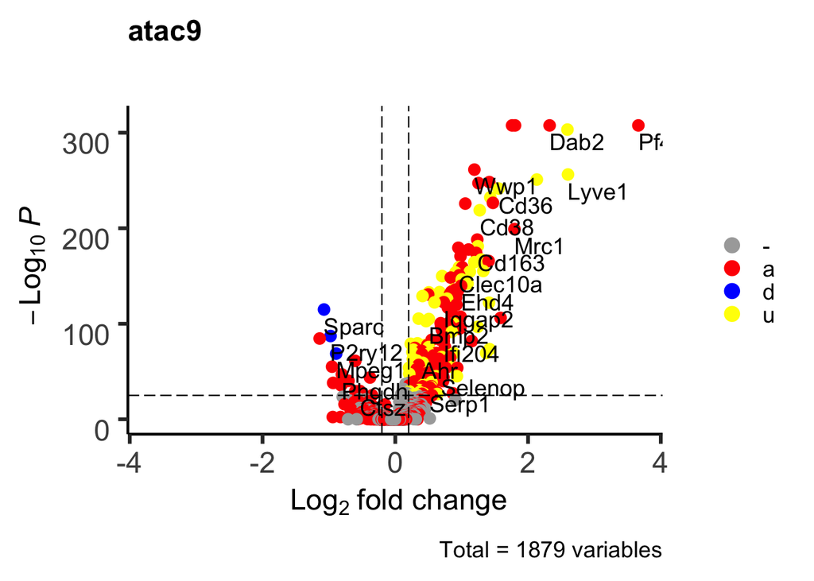

```r
newlist = list()

#Split by cluster
for (cluster in clusters){
  newlist[[cluster]] = de[de$cluster == cluster,]
}

#select a single cluster
for (cluster in clusters){
  fc = newlist[[cluster]]
  fc = fc[!is.na(fc$avg_logFC),]
  colorkeysdown = fc$gene[fc$avg_logFC < -log2(foldchange) & fc$p_val_adj < alpha]
  colorkeysup = fc$gene[fc$avg_logFC > log2(foldchange) & fc$p_val_adj < alpha]
  xlim = max(abs(fc$avg_logFC))
  atac = atac[atac$Peak.Score>5,]
  allcolors = rep("darkgrey",length(fc$gene))
  names(allcolors) = fc$gene
  allcolors[names(allcolors) %in% colorkeysdown] = "blue"
  allcolors[names(allcolors) %in% colorkeysup]= "yellow"
  allcolors[names(allcolors)%in% atac$gene] = "red"
  names(allcolors)[allcolors == "yellow"] = "u"
  names(allcolors)[allcolors == "darkgrey"] = "-"
  names(allcolors)[allcolors == "blue"] = "d"
  names(allcolors)[allcolors == "red"] = "a"

  setEPS()
  postscript(file.path(dir,"Plots",paste0(name,"_volcano_atac",cluster,"label.eps")))
  print(EnhancedVolcano(fc,
                lab = fc$gene,
                x = 'avg_logFC',
                y = 'p_val_adj',
                xlim = c(-xlim,xlim),
                title = paste0("atac",cluster),
                subtitle = "",
                drawConnectors = F,
                legendPosition = 'right',
                legendVisible = F,
                pCutoff = alpha,
                FCcutoff = log2(foldchange),
                selectLab = c(colorkeysdown,colorkeysup),
                transcriptPointSize = 3,
                transcriptLabSize = 5,
                col=c('black', 'black', 'black', 'red3'),
                colCustom = allcolors,
                gridlines.major = F,
                gridlines.minor = F,
                colAlpha = 1))
  dev.off()

  print(EnhancedVolcano(fc,
                lab = fc$gene,
                x = 'avg_logFC',
                y = 'p_val_adj',
                xlim = c(-xlim,xlim),
                title = paste0("atac",cluster),
                subtitle = "",
                drawConnectors = F,
                legendPosition = 'right',
                legendVisible = F,
                pCutoff = alpha,
                FCcutoff = log2(foldchange),
                selectLab = c(colorkeysdown,colorkeysup),
                transcriptPointSize = 3,
                transcriptLabSize = 5,
                col=c('black', 'black', 'black', 'red3'),
                colCustom = allcolors,
                gridlines.major = F,
                gridlines.minor = F,
                colAlpha = 1))

}
```

Make a table

Select only the diff. exp genes from atac-seq data

```r
atac$cluster = as.factor(atac$cluster)
de$cluster = as.factor(de$cluster)
atac = atac[atac$p_val_adj < alpha,]
atacup = atac[atac$avg_logFC > log2(foldchange),]
atacdown = atac[atac$avg_logFC < -log2(foldchange),]

atacup = table(atacup$cluster)
atacdown = table(atacdown$cluster)
```

compare to atac-seq data

```r
deup = de[de$avg_logFC>log2(foldchange) & de$p_val_adj <alpha,]
dedown = de[de$avg_logFC< -log2(foldchange) & de$p_val_adj <alpha,]

allup= table(deup$cluster)
alldown = table(dedown$cluster)

t = rbind(allup,atacup,pctup = round(atacup/allup*100,0),alldown,atacdown, pctdown = round(atacdown/alldown*100,0))
```

Bar chart

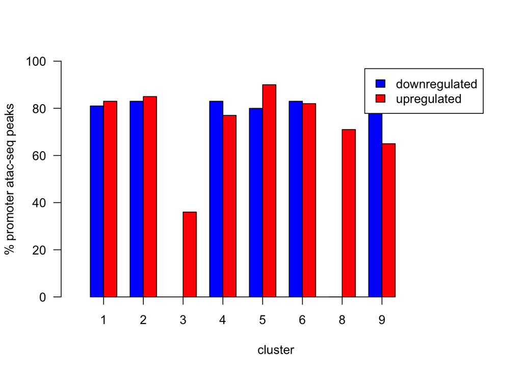

```r
#pull out exactly what you want to plot
p = t[c("pctdown","pctup"),]
c = barplot(p, horiz = F, las=1, xlim = c(0,30),xlab = "cluster", ylab = '% promoter atac-seq peaks',
        beside=T, col=c('blue','red'),ylim = c(0,100),legend = c("downregulated","upregulated"),axis.lty = 1)
```

```r
c
```

```
##      [,1] [,2] [,3] [,4] [,5] [,6] [,7] [,8]
## [1,]  1.5  4.5  7.5 10.5 13.5 16.5 19.5 22.5
## [2,]  2.5  5.5  8.5 11.5 14.5 17.5 20.5 23.5
```

```r
#actually make a bargraph of t$rup and t$rdown
setEPS()
postscript(file.path(dir,"Plots",paste0(name,"_barplot_atacseq_updown.eps")))
c
```

```
##      [,1] [,2] [,3] [,4] [,5] [,6] [,7] [,8]
## [1,]  1.5  4.5  7.5 10.5 13.5 16.5 19.5 22.5
## [2,]  2.5  5.5  8.5 11.5 14.5 17.5 20.5 23.5
```

```r
dev.off()
```

Cellphone db: also from jupyter, see python script for details. “X3.04” means from cluster 3 (source) to cluster 4 (target) count per interaction, remove rows with nothing

```r
colnames(cellphonedb)
```

```
##  [1] "id_cp_interaction"   "interacting_pair"    "partner_a"
##  [4] "partner_b"           "gene_a"              "gene_b"
##  [7] "secreted"            "receptor_a"          "receptor_b"
## [10] "annotation_strategy" "is_integrin"         "rank"
## [13] "X3.03"               "X3.04"               "X3.05"
## [16] "X3.08"               "X4.03"               "X4.04"
## [19] "X4.05"               "X4.08"               "X5.03"
## [22] "X5.04"               "X5.05"               "X5.08"
## [25] "X8.03"               "X8.04"               "X8.05"
## [28] "X8.08"
```

```r
cdb = cellphonedb[,13:28]
cdb = cdb[rowSums(cdb,na.rm = T)>0,]
```

Replace NA with 0 and any number with 1 (count incidents)

```r
cdb[!is.na(cdb)] = 1
cdb[is.na(cdb)] = 0
cd = colSums(cdb,na.rm = T)
cd
```

```
## X3.03 X3.04 X3.05 X3.08 X4.03 X4.04 X4.05 X4.08 X5.03 X5.04 X5.05 X5.08 X8.03
##    49    42    37    30    38    33    37    34    24    28    30    25    39
## X8.04 X8.05 X8.08
##    26    28    23
```

**Make a table(*

First we will repeat the names for source and target and then rename source and target to the appropriate portions of the name itself.

```r
cd = rbind("Source" = names(cd),"Target" = names(cd),"interactions" = cd)
cd["Source",] = sapply(cd["Source",],function(x)paste0("Source_",strsplit(x,"")[[1]][2]))
cd["Target",] = sapply(cd["Target",],function(x)strsplit(x,"\\.")[[1]][2]) #split on ".", take 2nd
cd["Target",] =sapply(cd["Target",],function(x)paste0("Target_",strsplit(x,"")[[1]][2])) #remove "0"
```

Make a 3D table first, then iterate through each matrix and add the 3rd dimension (#interactions) to its appropriate position

```r
x = table(cd["Source",],cd["Target",],cd["interactions",])
dimnames(x)
```

```
## [[1]]
## [1] "Source_3" "Source_4" "Source_5" "Source_8"
##
## [[2]]
## [1] "Target_3" "Target_4" "Target_5" "Target_8"
##
## [[3]]
##  [1] "23" "24" "25" "26" "28" "30" "33" "34" "37" "38" "39" "42" "49"
```

```r
dim(x)[3]
```

```
## [1] 13
```

```r
a = x[,,1]
for (i in 1:dim(x)[3]){
  t = x[,,i]
  a[t == 1] = dimnames(x)[[3]][i]
}
```

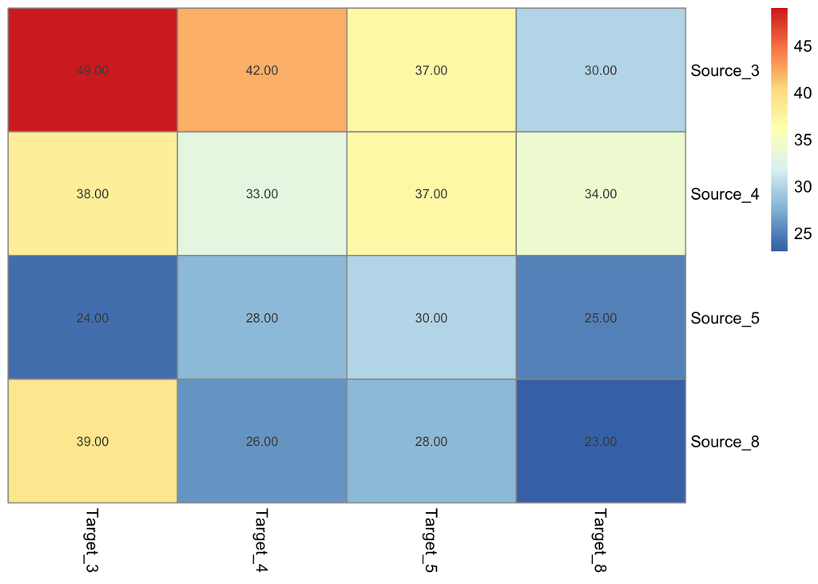

```r
b = as.matrix.data.frame(a,rownames.force = T)
colnames(b) = colnames(a)
b = apply(b,MARGIN = c(1,2), function(x)as.numeric(x))

pheatmap(b, display_numbers = T,scale = "none",cluster_cols = F,cluster_rows = F )
```

```r
setEPS()
postscript(file.path(dir,"Plots",paste0(name,"heatmap_cellphonedb.eps")))
pheatmap(b, display_numbers = T,scale = "none",cluster_cols = F,cluster_rows = F,color = c("lightgrey","lightyellow","gold","orange","darkorange","red","darkred" ))
dev.off()
```

```
## postscript
##          3
```